# PLPCC02 - Lab 1 - Checkpoint 2

## Tiago Lucas Pereira Clementino

```r
library(tidyverse)
library(here)
library(knitr)
theme_set(theme_bw())
options(warn=-1)
```

# Dados

Os dados foram coletados a partir da operação da plataforma aberta de integração contínua Travistorent. Estes descrevem operações inerentes ao andamento de projetos no Github e a procedimentos de Integração Contínua (testes, *commits*, PR, *build* de integração, etc) ao longo de um certo período de tempo.

A integração contínua é um processo onde o desenvolvedor integra o código alterado e/ou desenvolvido ao projeto principal na mesma frequência com que as funcionalidades são introduzidas.

Nossa intenção é analisar os dados fazendo um paralelo entre as linguagens de programação Java e Ruby, levantando questões inerentes às características dos projetos de software que as utilizam. Diante disto, descartamos qualquer dados referentes a outras linguagens.

```r
projetos = read_csv(here::here("data/projetos.csv"))
projetos = projetos %>%
    filter(lang != "javascript")
```

## Variáveis

Nossa base de dados conta com variáveis bem intuitivas.

```r
projetos %>% names()
```

```
##  [1] "gh_project_name"       "team"
##  [3] "lang"                  "sloc_end"
##  [5] "sloc_med"              "activity_period"
##  [7] "num_commits"           "commits_per_month"
##  [9] "tests_per_kloc"        "total_builds"
## [11] "build_success_prop"    "builds_per_month"
## [13] "tests_added_per_build" "tests_successful"
## [15] "test_density"          "test_size_avg"
```

Cada uma delas descreve alguma característica dos projetos.

| Nome | Descrição |
| --- | --- |
| “gh_project_name” | nome do projeto |
| “team” | total de desenvolvedores que participaram do projeto até sua última medição |
| “lang” | linguagem de programação predominante |
| “sloc_end” | total de linhas de código na última medição do projeto |
| “sloc_med” | total de linhas de código no meio do tempo de atividade estimado do projeto |
| “activity_period” | tempo de atividade estimado do projeto |
| “num_commits” | total de submissões de alteração durante todo o tempo de atividade do projeto |
| “commits_per_month” | total de submissões por mês |
| “tests_per_kloc” | casos de teste por total de linhas de código |
| “total_builds” | total de integrações |
| “build_success_prop” | proporção de integrações bem-sucedidas |
| “builds_per_month” | total médio de integrações por mês |
| “tests_added_per_build” | total médio de testes adicionados por integração |
| “tests_successful” | total de testes bem-sucedidos |
| “test_density” | densidade de testes |
| “test_size_avg” | tamanho médio dos casos de testes |

Na nossa análise usaremos apenas as variáveis “team”, “lang” e “build_success_prop”.

## Distribuições dos dados

Distribuição dos dados entre as linguagens de programação Java e Ruby.

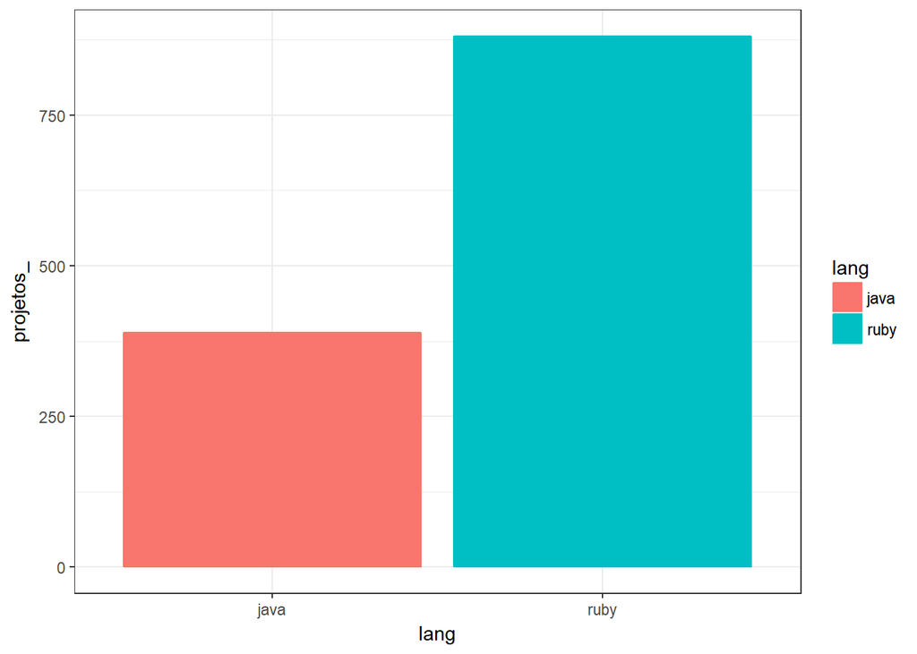

```r
projetos %>%
    group_by(lang) %>%
    summarise(projetos_ = n()) %>%
    ggplot(aes(x = lang, y = projetos_, fill = lang, color= lang)) +
    geom_col()
```

# Análise

A partir daqui analisaremos nossos dados com base em duas questões importantes, a primeira é como o tamanho da equipe se comporta na nossa base de dados em relação as linguagens de programação Java e Ruby, e a segunda é como projetos grandes (10 integrantes ou mais) variam na proporção de integrações bem-sucedidas em função das mesmas duas linguagens. Nosso objetivo aqui é identificar características e peculiaridades dos dados basicamente em função da linguagem de programação, do tamanho da equipe de desenvolvimento e da proporção de integração de alterações.

## Distribuição do tamanho de equipes para Java e Ruby

Aqui pretendemos fazer uma análise da variável “tamanho da equipe” presente nos dados, deixando o alvo desta análise em aberto.

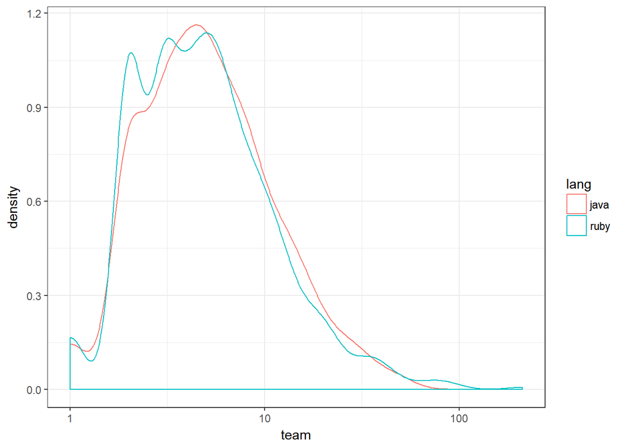

```r
projetos %>%
    ggplot(aes(x= team, color = lang)) +
    scale_x_log10() +
    geom_density()
```

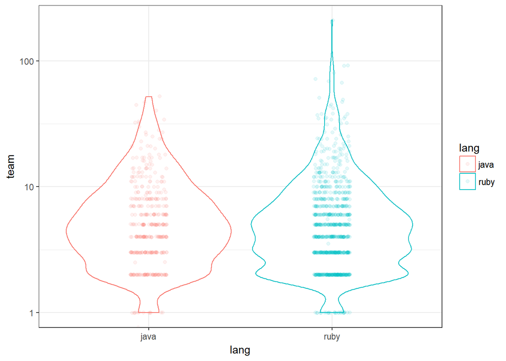

```r
projetos %>%
    ggplot(aes(y = team,
               x = lang, color= lang)) +
    geom_violin() +
    scale_y_log10() +
    geom_jitter(width = .1, alpha = .1)
```

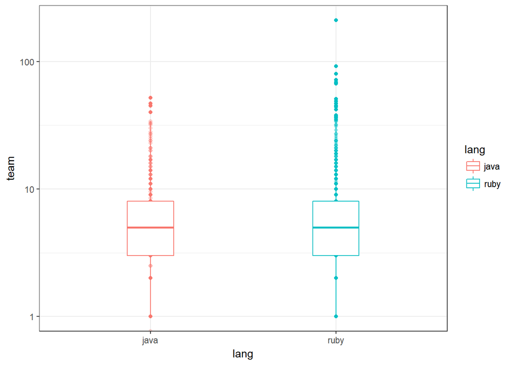

```r
projetos %>%
    ggplot(aes(x = lang,
               y = team, color=lang)) +
    geom_point(alpha = .3) +
    scale_y_log10()+
    geom_boxplot(width = .25)
```

Com base nos gráficos acima podemos ver que há uma predominância de equipes entre dois e dez integrantes, sobretudo com 4 ou 5 pessoas. Ruby parece estar mais distribuída em uma faixa de valores um pouco mais densa, um valor máximo maior de 200, o que destoa do conjunto.

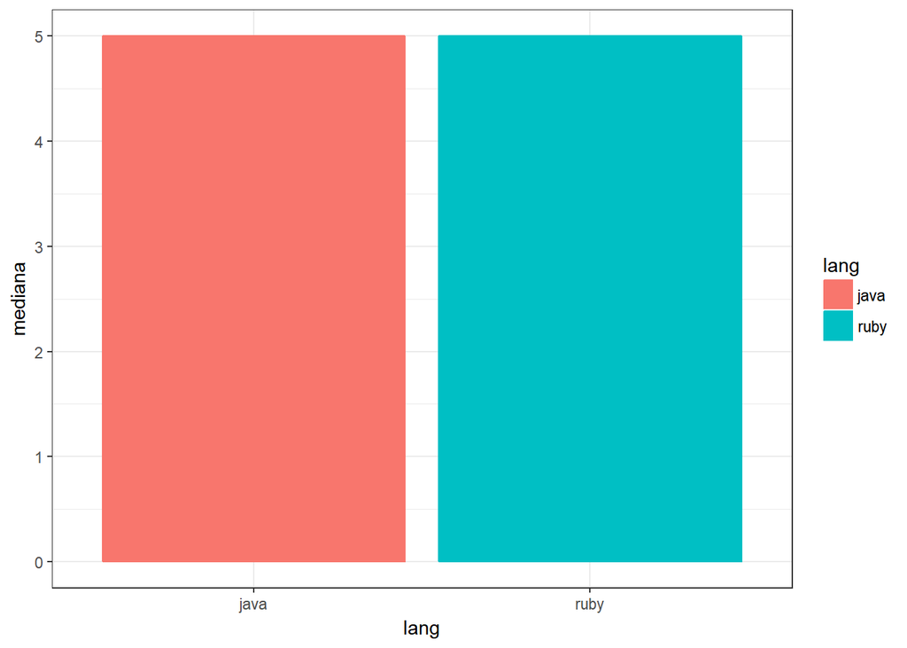

```r
projetos %>%
    group_by(lang) %>%
    summarise(mediana = median(team)) %>%
    ggplot(aes(x = lang, y = mediana, fill = lang, color= lang)) +
    geom_col()
```

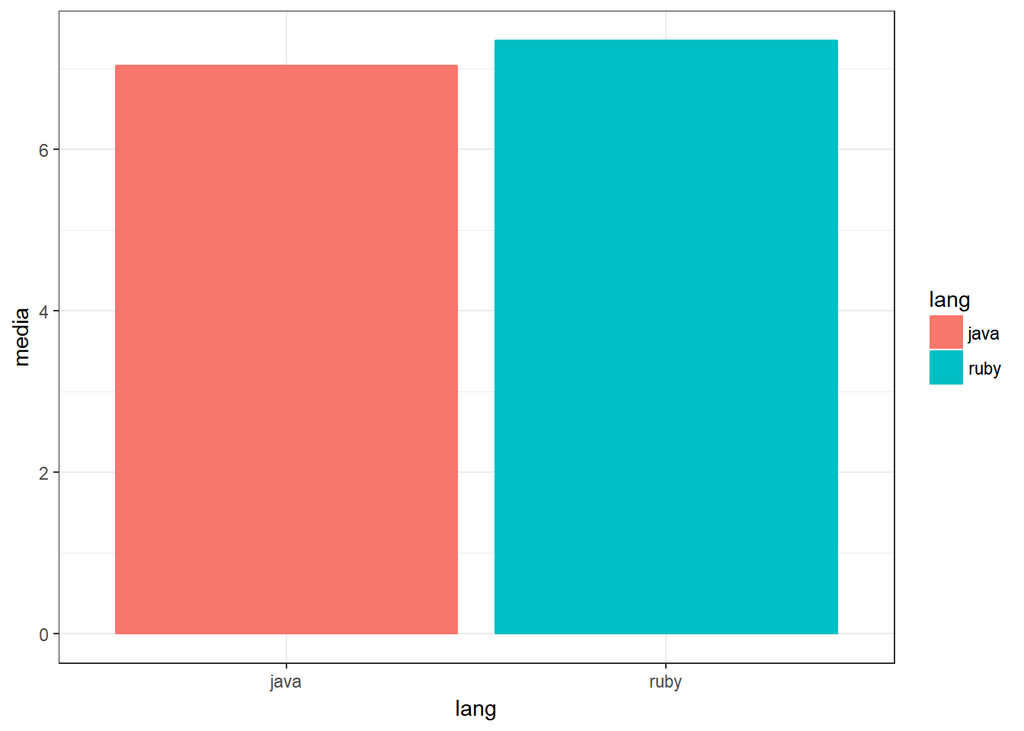

```r
projetos %>%
    group_by(lang) %>%
    summarise(media = mean(team)) %>%
    ggplot(aes(x = lang, y = media, fill = lang, color= lang)) +
    geom_col()
```

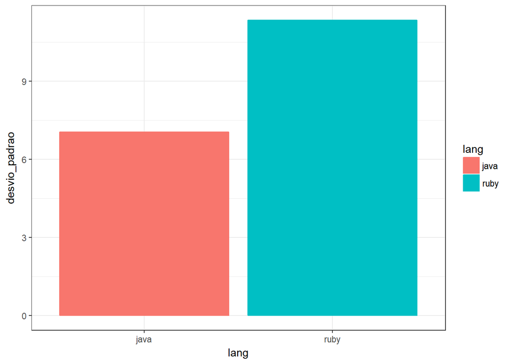

```r
projetos %>%
    group_by(lang) %>%
    summarise(desvio_padrao = sd(team)) %>%
    ggplot(aes(x = lang, y = desvio_padrao, fill = lang, color= lang)) +
    geom_col()
```

Dos gráficos apresentados acima, os dois resultados mais relevantes são: O total de desenvolvedores mais central nos dados é 5 tanto em Java quanto em Ruby (como os gráficos anteriores mostraram), o que sugere um equilíbrio. O segundo resultado importante é a diferença entre as taxas de variação de Java (aproximadamente 7) e Ruby (aproximadamente 11), sendo Java bem menor. Isto indica uma maior homogeneidade nos dados de Java.

## Variação na proporção de integrações bem sucedidas para projetos com grandes equipes em função da linguagem

Eliminar os projetos com menos de 10 membros na equipe equivale a descartar a maior parte da base de dados, o que altera bastante a distribuição dos dados. Como veremos em seguida, algumas medidas centrais dos dados foram reposicionadas.

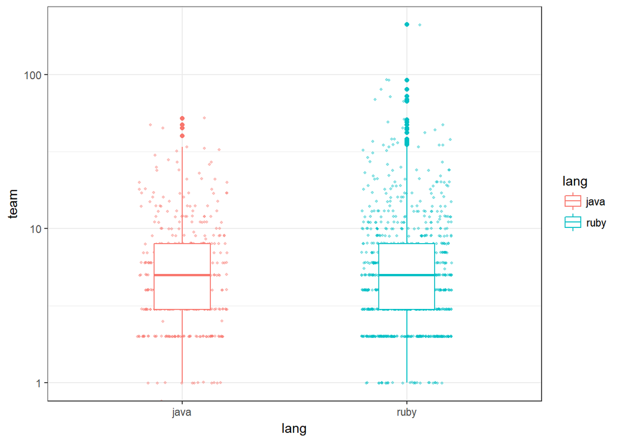

```r
projetos %>%
    ggplot(aes(x = lang,
               y = team,color=lang)) +
    geom_jitter(alpha = .4, width = .2, size = .8) +
    scale_y_log10()+
    geom_boxplot(width = .25)
```

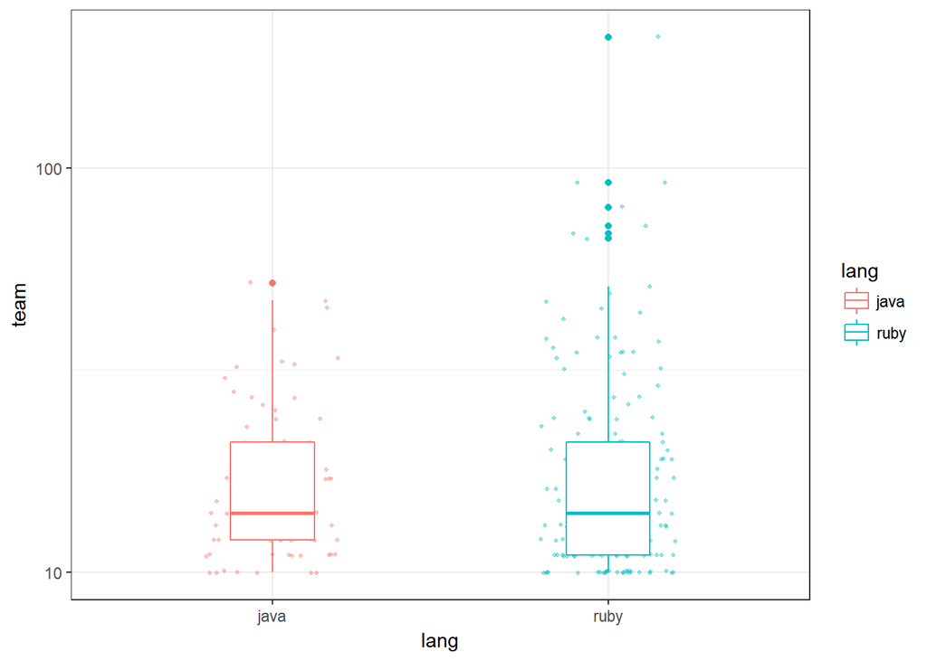

```r
projetos %>%
    filter(team>=10) %>%
    ggplot(aes(x = lang,
               y = team,color=lang)) +
    geom_jitter(alpha = .4, width = .2, size = .8) +
    scale_y_log10()+
    geom_boxplot(width = .25)
```

Os dois gráficos acima apresentam a disposição das quantidades de integrantes para cada equipe de todos os dados e do conjunto filtrado para valores superiores a 10. Perceba que houve uma grande distorção.

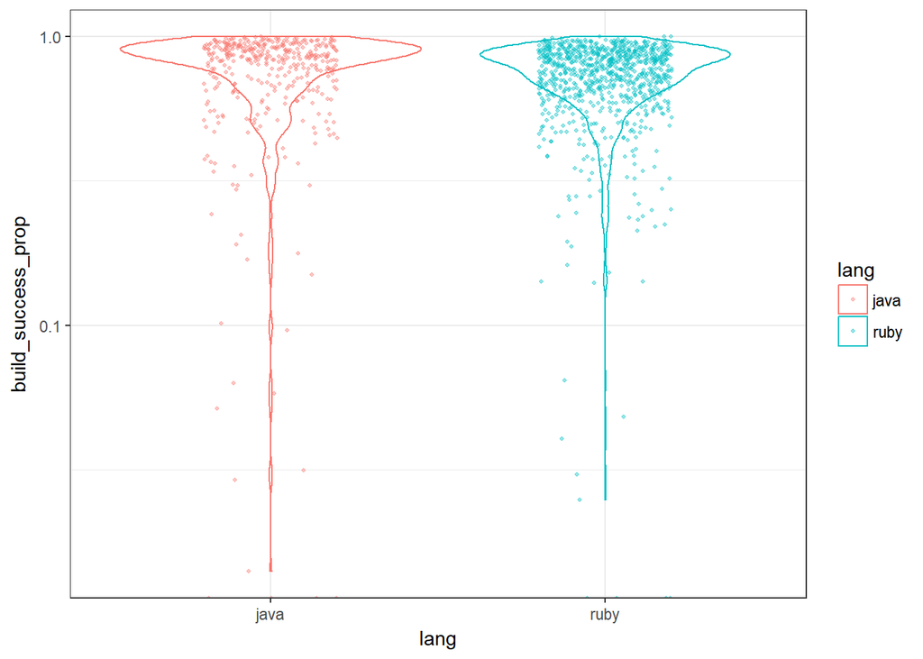

```r
projetos %>%
    ggplot(aes(x = lang,
               y = build_success_prop,color=lang)) +
    geom_violin() +
    geom_jitter(alpha = .4, width = .2, size = .8) +
    scale_y_log10()
```

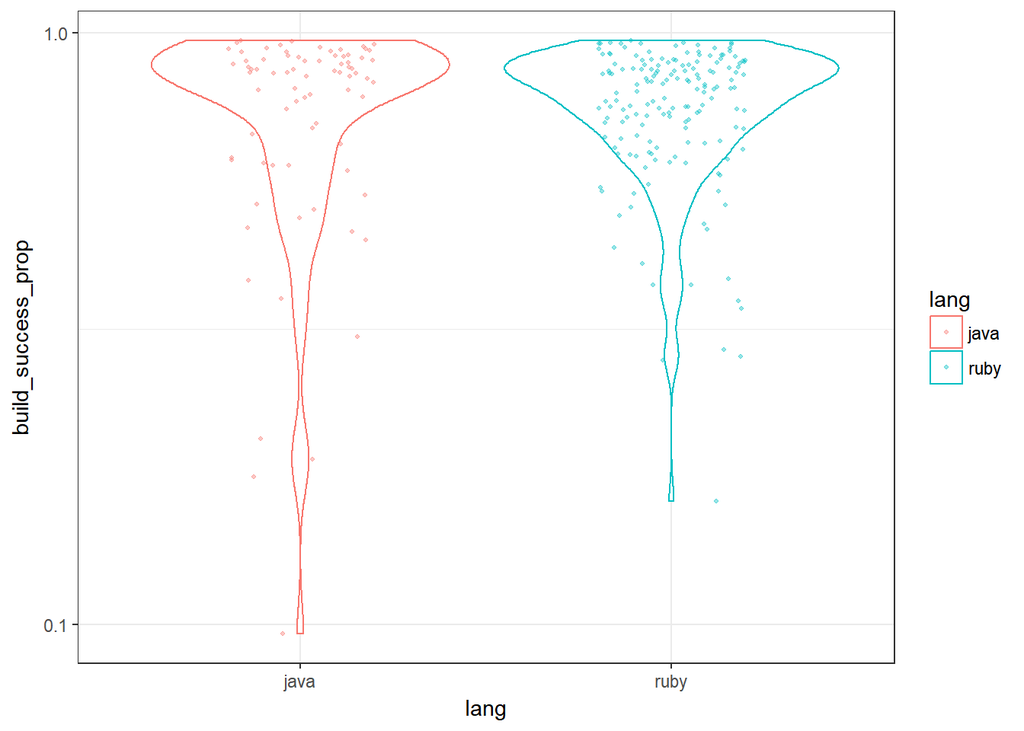

```r
projetos %>%
    filter(team>=10) %>%
    ggplot(aes(x = lang,
               y = build_success_prop,color=lang)) +
    geom_violin() +
    geom_jitter(alpha = .4, width = .2, size = .8) +
    scale_y_log10()
```

O mesmo ocorre quando observamos a proporção de integrações bem-sucedidas. Perceba que o segundo gráfico, referente à amostra filtrada (equipe >= 10), é muito mais disperso.

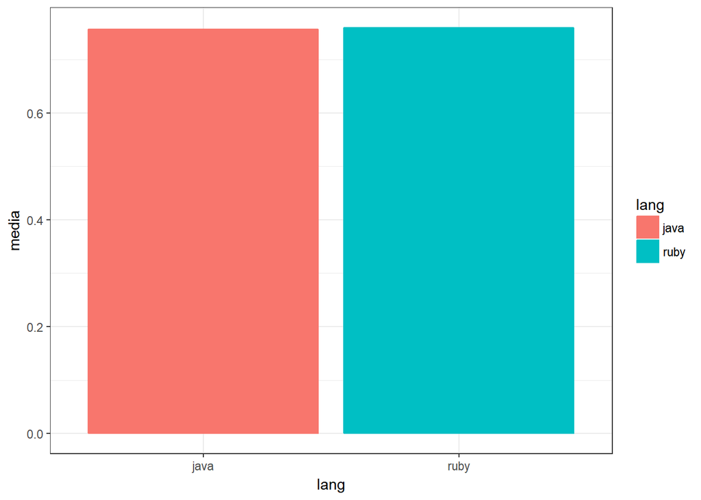

```r
projetos %>%
    filter(team>=10) %>%
    group_by(lang) %>%
    summarise(media = mean(build_success_prop)) %>%
    ggplot(aes(x = lang, y = media, fill = lang, color = lang)) +
    geom_col()
```

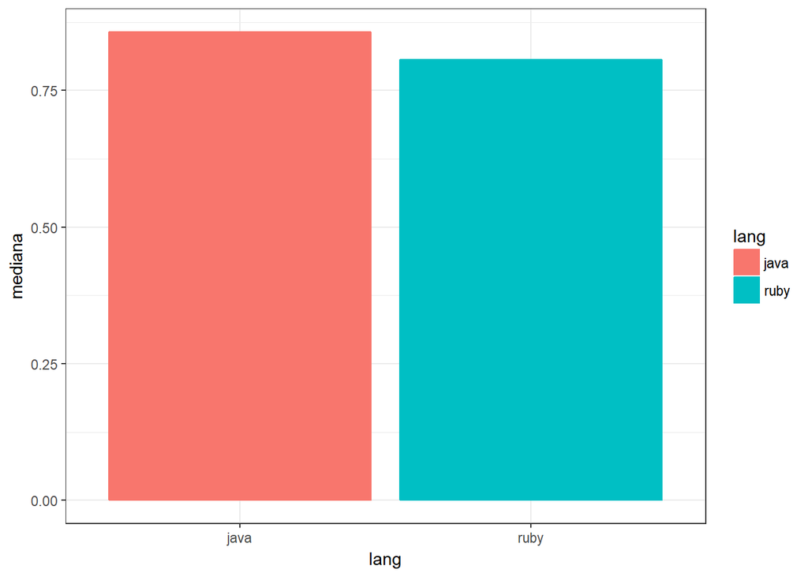

```r
projetos %>%
    filter(team>=10) %>%
    group_by(lang) %>%
    summarise(mediana = median(build_success_prop)) %>%
    ggplot(aes(x = lang, y = mediana, fill = lang, color = lang)) +
    geom_col()
```

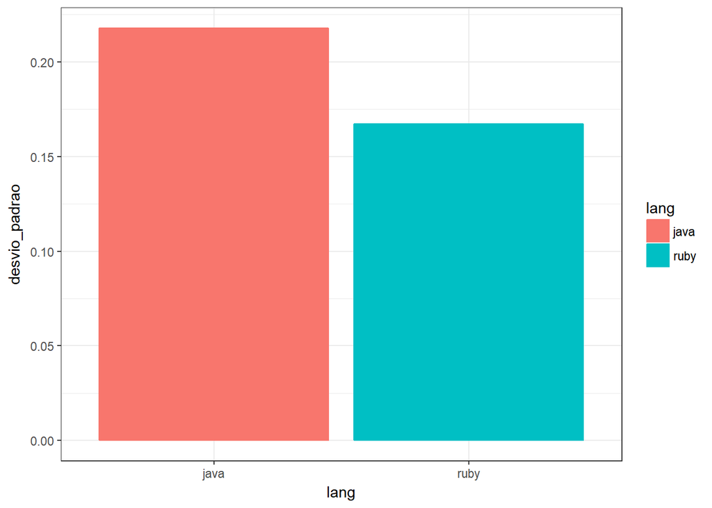

```r
projetos %>%
    filter(team>=10) %>%
    group_by(lang) %>%
    summarise(desvio_padrao = sd(build_success_prop)) %>%
    ggplot(aes(x = lang, y = desvio_padrao, fill = lang, color = lang)) +
    geom_col()
```

Aqui finalmente comparamos a variação da proporção de integrações bem-sucedidas nos dados filtrados (equipe >= 10). Para isto tomamos três valores, cada um exposto em um gráfico acima: O valor médio, representando a proporção de integrações bem-sucedidas de cada projeto dividida pelo total de projetos para cada linguagem, o valor central (mediana), representando o projeto que divide os dados ordenados ao meio, e a taxa de variação desta variável.

O valor médio desta variável para o conjunto filtrada mostra-se extremamente equilibrado, como é possível ver no gráfica, tendo as duas linguagens praticamente o mesmo resultado (algo em torno de 0.75). O valor central, que representa o projeto que divide os dados igualmente entre maiores e menores, apresenta uma certa vantagem para linguagem Java.

Finalmente, a taxa de variação da proporção de integrações bem-sucedidas descrita no terceiro gráfico também apresenta vantagem para Java.

Tento o valor médio bastante equilibrado entre as linguagens e uma vantagem para Java no valor central, já poderíamos ter concluído que a taxa de variação entre os projetos Java para esta variável é superior. O gráfico que descreve esta variação só confirma o que já parecia claro, projetos Java variam bem mais no que diz respeito a proporção de integrações bem-sucedidas.